# Progress Memo 1

Final Project  
Data Science 1 with R (STAT 301-1)

Author

Freesia Tokunaga

Published

November 22, 2023

**Github Repo Link**

https://github.com/stat301-1-2023-fall/final-project-1-freesiat.git

## Data source

The Japanese healthcare facility data was obtained from [this website](https://data.humdata.org/dataset/japan-healthsites). The dataset is part of the **Global Healthsites Mapping Project**, an initiative to make health facility data in every country accessible to anyone across the globe. More about the project can be read [here](https://healthsites.io/).

The estimate of the percentage of elderly populations (those over 65 years old) in each Japanese city was obtained from [this website](https://www.ipss.go.jp/pp-shicyoson/j/shicyoson08/t-page.asp). This data was published by the **National Institute of Population and Social Security Research of Japan** in 2008. It must be noted that this data was only available in Japanese, so I had to translate the name of each city to English, and then create a new dataset with the English name and then I selected 2020 as the year of interest. It should also be noted that the percentage of elderly population of 2020 is an **estimate**. They estimated this number **based on data from 2005**. Unfortunately, I was unable to find any observed data of the elderly population from 2020 which was divided up by city, which is why I used this dataset.

Finally, the geographical data of Japan was obtained via the `getData` function in the `raster` package by specifying the dataset to be `GADM`. Then, I added in the `country = JPN` argument to specify geographic data from Japan. Finally, I set the `level` to 2 to obtain the boundaries for all of the cities and towns in Japan so that they are reflected onto the map. I then transformed the data so that it can be read in through `geom_sf` and be visualized.

## Why this data

As a global health major, I have always been interested in the distribution and accessibility of healthcare facilities. There are countless ways to quantify the accessibility of healthcare facilities, but for this project, I decided to focus on its geographical accessibility in my home country, Japan. Japan is a rapidly aging country with nearly 30% of its population aged 65 years old and above, the highest percentage in the world. However, the elderly population is distributed unequally across Japan, with a much higher number in rural regions. Despite the elderly population needing the most healthcare services, an increasingly major concern is that facilities are not as readily available in rural areas. Therefore, the aim of my project is to compare the number of healthcare facilities available in each city in Japan to the percentage of citizens over 65 years old in that city, as well as the type of healthcare facility available (pharmacy, physician’s office, hospital, etc). Through visualizing this data, the disparities, if any, of healthcare facilities across Japan will become apparent, and could become a starting point to understanding which cities need more of what kind of health facility.

## Data quality & complexity check

```
# A tibble: 1,851 × 2
   city           year_2020_percentage
   <chr>                         <dbl>
 1 Sapporo                        28
 2 hakodate city                  35.4
 3 Otaru City                     39.8
 4 Asahikawa City                 35.6
 5 Muroran City                   37
 6 Kushiro City                   33.9
 7 Obihiro City                   31.1
 8 Kitami City                    33.7
 9 Yubari City                    49.7
10 Iwamizawa City                 35
# ℹ 1,841 more rows
```

```
Simple feature collection with 1811 features and 13 fields
Geometry type: MULTIPOLYGON
Dimension:     XY
Bounding box:  xmin: 122.9332 ymin: 24.04542 xmax: 153.9869 ymax: 45.52279
Geodetic CRS:  +proj=longlat +datum=WGS84 +no_defs
First 10 features:
       gid_0 name_0   gid_1 name_1 nl_name_1      gid_2   name_2 varname_2
184372   JPN  Japan JPN.1_1  Aichi    愛知県  JPN.1.1_1     Agui      <NA>
184193   JPN  Japan JPN.1_1  Aichi    愛知県  JPN.1.2_1    Aisai      <NA>
184346   JPN  Japan JPN.1_1  Aichi    愛知県  JPN.1.3_1     Anjō      <NA>
184340   JPN  Japan JPN.1_1  Aichi    愛知県  JPN.1.4_1   Chiryū      <NA>
184344   JPN  Japan JPN.1_1  Aichi    愛知県  JPN.1.5_1    Chita      <NA>
184091   JPN  Japan JPN.1_1  Aichi    愛知県  JPN.1.6_1     Fusō      <NA>
184441   JPN  Japan JPN.1_1  Aichi    愛知県  JPN.1.7_1 Gamagōri      <NA>
184394   JPN  Japan JPN.1_1  Aichi    愛知県  JPN.1.8_1    Handa      <NA>
184186   JPN  Japan JPN.1_1  Aichi    愛知県  JPN.1.9_1   Haruhi      <NA>
184468   JPN  Japan JPN.1_1  Aichi    愛知県 JPN.1.10_1     Hazu      <NA>
       nl_name_2 type_2 engtype_2 cc_2   hasc_2                       geometry
184372  阿久比町  Machi      Town <NA>     <NA> MULTIPOLYGON (((136.8803 34...
184193    愛西市    Shi      City <NA>     <NA> MULTIPOLYGON (((136.7044 35...
184346    安城市    Shi      City <NA>     <NA> MULTIPOLYGON (((137.1247 34...
184340    知立市    Shi      City <NA>     <NA> MULTIPOLYGON (((137.06 34.9...
184344    知多市    Shi      City <NA> JP.AI.CG MULTIPOLYGON (((136.8256 34...
184091    扶桑町  Machi      Town <NA>     <NA> MULTIPOLYGON (((136.947 35....
184441    蒲郡市    Shi      City <NA>     <NA> MULTIPOLYGON (((137.2346 34...
184394    半田市    Shi      City <NA> JP.AI.HD MULTIPOLYGON (((136.9281 34...
184186    春日町  Machi      Town <NA> JP.AI.HG MULTIPOLYGON (((136.8576 35...
184468    幡豆町  Machi      Town <NA> JP.AI.HZ MULTIPOLYGON (((137.1464 34...
```

### Dataset 1 - Japan Healthcare Sites

In this dataset, we have 56596 observations with 2 numerical and 1 categorical variable after cleaning the data and selecting for only the variables of interest. The 2 numerical variables are the longitude and latitude of the position of the healthcare facility, and the categorical variable (amenity) tells us what type of healthcare facility it is. Upon checking the missingness of the data, we see a 78% completion rate for the latitude and longitude variables, and a nearly 100% completion rate for the amenity variable.

### Dataset 2 - Japan Geriatric Population Data

In this dataset, we have 1851 observations of two variables after cleaning the data. The categorical variable is the name of the city, and the numerical variable is the percentage of citizens over 65 years old living in that city. There are no missing observations.

### Dataset 3 - Japan Map Data

In this dataset, we have 1811 observations of 14 variables. Of them, the only ones of interest are `NAME_2`, which gives us the name of the city, and `geometry`, which gives us the multipolygon data to map the datapoints onto the map to visualize the Japanese island and the borders of every single city/town within it. `ENGTYPE_2` is also of interest, since it tells us the classification of the city. It is divided up into factor levels; `town`, `city`, `village`, or `special ward`. It would be interesting to examine the correlation between the city classification and density of healthcare facilities as well. There are no missingness issues for the variables of interest.

## Potential data issues

The first issue at hand is that we do not know whether the city/towns listed in the Japan Map dataset match those in the Japan Geriatric Population dataset. This may result in some cities having to be removed from the analysis since we cannot map the correlation onto the map if the cities don’t match up. Another issue that needs to be looked into is the missingness of the Japan Healthcare Sites dataset; it must be noted in the analysis that 22% of healthcare facilities cannot be mapped due to the lack of coordinates data.

Most of these issues can be resolved by cleaning the data, where the process is described below.

## Cleaning Data

### Dataset 1 - Japan Healthcare Sites

Only the `X` (latitude), `Y` (longitude), and `amenity` (healthcare facility type) variables were selected by piping the dataset into the `dplyr::select()` function.

### Dataset 2 - Japan Geriatric Population Data

After translating the Japanese names into English and selecting for the estimated geriatric population percentage for the year 2020, I imported the dataset and then removed the word “city” from each observation by using the `mutate` function and then the `word` function which I used to select only the first word of each observation. Then, I selected for the city name and the percentage of citizens over 65 years old.

### Combining all 3 datasets together

First, I used `left_join` to combine the geriatric population data and the map data together, which eliminated data for all cities that weren’t present in the map dataset. Then, I removed all rows that contained missing values for the geriatric population percentage. Then, I converted the healthcare sites data into an sf object so that it can be visualized onto the map. Finally, I joined the healthcare sites data to the larger dataset by matching the city that the healthcare site belonged to by passing in a function that checked the given coordinates and matched them to the appropriate multipolygon object present in the maps dataset.

## EDA

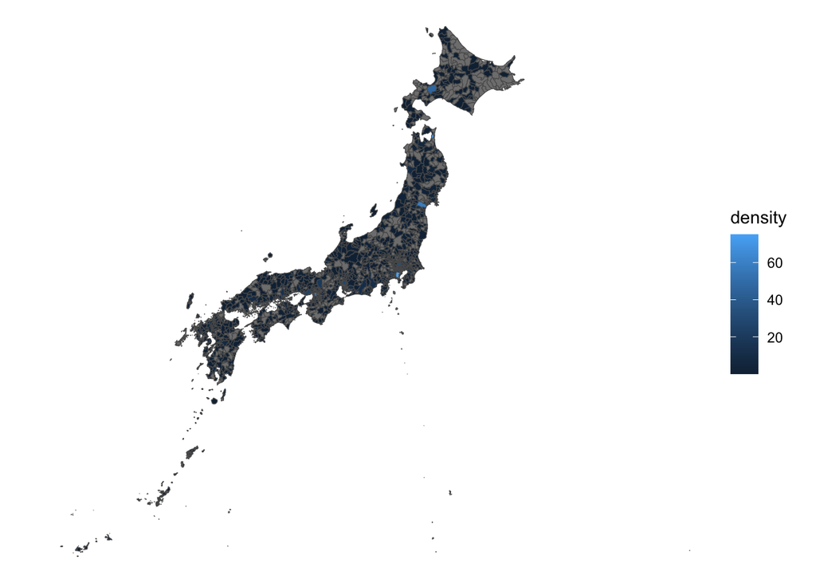

The plot above shows the distribution of healthcare facilities all over Japan

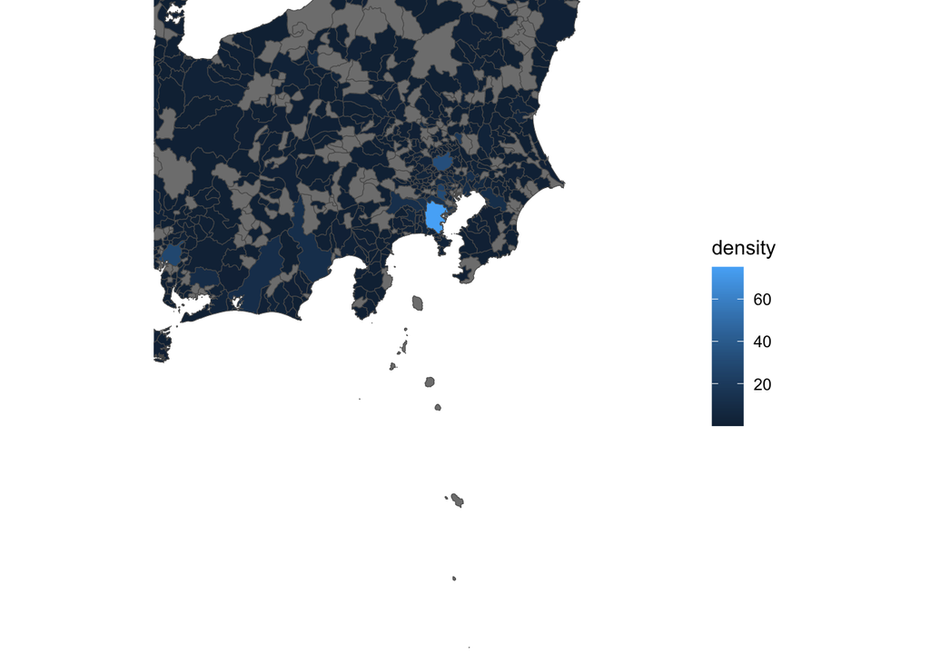

The plot above zooms into the Kanto region.

## Misc

I learned how to map geographical data from the `GADM` dataset through watching [this YouTube video](https://www.youtube.com/watch?app=desktop&v=Qbkx3LCguyg) by **Lab Time with R & Python**. I also learned how to fill in each city with a corresponding variable and its appropriate color scale through [this tutorial](https://mattherman.info/blog/point-in-poly/) by *Matt Herman*